# Exam 1

## Exam 1

#### Metainformation

1. | Tag | Value |
   | --- | --- |
   | `file` | Inferential_Statistics_vufsw-twoway_anova-1328-nl_vufsw-twoway_anova-1328-nl |
   | `name` | vufsw-twoway anova-1328-nl |
   | `section` | inferential statistics/parametric techniques/anova/twoway anova |
   | `type` | schoice |
   | `solution` | FALSE, TRUE, FALSE, FALSE |
   | `Type` | interpreting output |
   | `Program` | NA |
   | `Language` | dutch |
   | `Level` | statistical literacy |

#### Question

   Field beweert dat er een toename is in het aantal spierblessures als gevolg van het spelen van het computerspel Wii van Nintendo. Een onderzoekster verwacht dat mensen die sporten hier minder last van hebben, omdat ze al gewend zijn aan lichaamsbeweging. Voor de niet-sporters verwacht ze dat een warming-up voorafgaand aan een Wii sessie zal helpen om deze blessures te voorkomen.

   Hieronder staan de resultaten van de analyse.

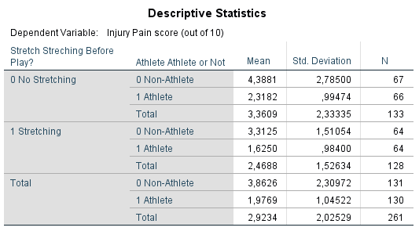

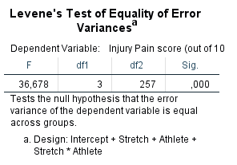

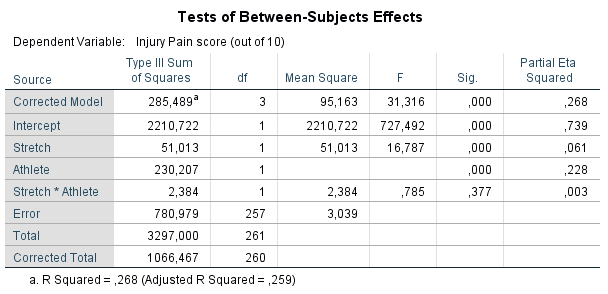

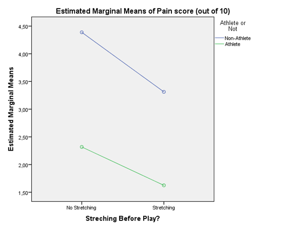

   Welk van de onderstaande *F*-waarden toetst of er verschillen zijn in de gemiddelde pijnklachten tussen de vier onderscheiden groepen?
   1. **FALSE:** .785
   2. **TRUE:** 31.316
   3. **FALSE:** 36.678
   4. **FALSE:** 727.492
   1. False
   2. True
   3. False
   4. False